# Project 1: SAT & ACT Analysis

Syamil M.

## Problem Statement

In 2016, the College Board released a new SAT format to reflect changing trends in college education and to better prepare students for college <sup>1</sup>. While test preferences differ from state to state, SAT participation rates in 2018 saw a 25% increase from 2017 with 2018 having the largest number of SAT test takers since the inception of the SAT <sup>2</sup>.

At the same time, the colleges throughout America are dropping standardised tests such as the ACT and SAT in favour of more streamlined admissions assessment policies <sup>3</sup>. Clearly, this poses a challenge for the future of standardised testing in which the SAT has an intrinsic stake.

## Executive Summary

In light of this challenge, aggregated data from the 2017 and 2018 cohort for the SAT and ACT assessments across the 51 United States Districts have been used in this report to better understand key trends in participation rates as well as provide new ways to look into further improving SAT participation rates.

From the analysis, lowering barriers towards participation via SAT School Days on top of enabling easy access to fee waivers had a clear impact in a number of states towards improving SAT participation.

In some cases, we see a ten-fold increase in SAT participation for one particular state, Illinois, that made the SAT its state-wide college entrance exam.

### Libraries Used:

```python
#Imports:
import pandas as pd
import numpy as np
```

## Outside Research

We have thus uncovered key points from the visualisations and prior analyses:

1. The ACT has a higher median participation rate when compared to the SAT.
2. Florida and Georgia which had >50% in both tests showed a YoY increase of SAT and a decrease in ACT participation rates.
3. Illinois had a significant increase (tenfold) in SAT participation.

### State Policies on SAT/ACT and Impact to Participation

In this section, we will assess if state-level policies on SAT/ACT preferences as part of high school requirements have an impact on overall participation rates. The image below provides an overview of the 2018 landscape of the SAT/ACT requirements for each state<sup>5</sup>.

[figure not shown]

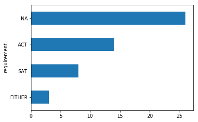

```python
# Count of Requirements
merged_requirements.groupby('requirement').state.count().sort_values().plot.barh()
```

#### State Policies on SAT/ACT and impact to Participation %

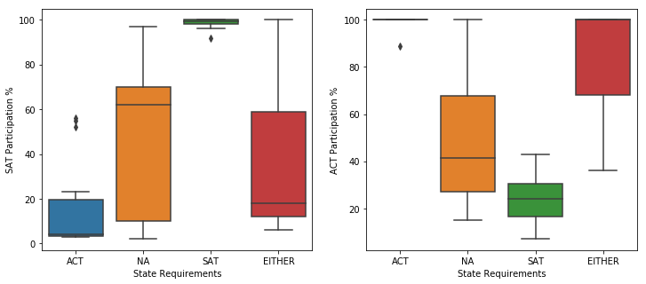

```python
f, (ax1, ax2) = plt.subplots(1, 2,figsize=(12,5))
sns.boxplot(x="requirement",y="Participation_sat2018",data=merged_requirements,ax=ax1)
sns.boxplot(x="requirement",y="Participation_act2018",data=merged_requirements,ax=ax2)
ax1.set_xlabel('State Requirements')
ax2.set_xlabel('State Requirements')
ax1.set_ylabel("SAT Participation %")
ax2.set_ylabel("ACT Participation %")
```

In states where SAT is mandatory, the participation rate is close to 100%. At the same time, for states that do not have either SAT or ACT mandatory, there is a higher tendency for students to prefer SATs over ACTs.

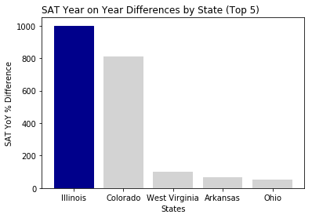

```python
# add in addtional columns to illustration percentage difference YoY
def pct_diff_sat(row):
    row['sat_pct_diff'] = round(((row['Participation_sat2018']-row['Participation_sat2017'])\
                        / row['Participation_sat2017'] * 100),2)
    return row

filter_chart = merged_requirements.apply(pct_diff_sat,axis=1).sort_values(by=['sat_pct_diff'],ascending=False).head(5)
barplot = plt.bar(x=filter_chart['state'],height=filter_chart['sat_pct_diff'], color = 'lightgrey')
barplot[0].set_color('darkblue')
plt.xlabel('States', fontsize = 10)
plt.ylabel('SAT YoY % Difference', fontsize = 10)
plt.title('SAT Year on Year Differences by State (Top 5)',loc='left')
```

States such as Illinois, Colorado and West Virginia saw a marked rise in SAT participation with illinois having a 10 fold increase due to state-level policies that saw SAT being the college exam standard for all public schools in the state<sup>5</sup>.

### Reducing Barriers to Entry

```python
final_participation = merged_requirements[(merged_requirements['Participation_act2018']  > 50) & (merged_requirements['Participation_sat2018'] > 50) \
                                & (merged_requirements['Participation_act2017']  > 50) & (merged_requirements['Participation_sat2017'] > 50)]\
                            .loc[:,merged_requirements.columns.to_series().str.contains('Participation|state|requirement')].copy()

final_participation
```

|  | state | Participation_sat2018 | Participation_act2018 | Participation_sat2017 | Participation_act2017 | requirement |
| --- | --- | --- | --- | --- | --- | --- |
| 9 | Florida | 97 | 66 | 83 | 73 | NA |
| 10 | Georgia | 70 | 53 | 61 | 55 | NA |
| 11 | Hawaii | 56 | 89 | 55 | 90 | ACT |

### Trends in ACT Performance

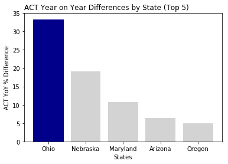

```python
def pct_diff_act(row):
    row['act_pct_diff'] = round(((row['Participation_act2018']-row['Participation_act2017'])\
                        / row['Participation_act2017'] * 100),2)
    return row
filter_chart = merged_requirements.apply(pct_diff_act,axis=1).sort_values(by=['act_pct_diff'],ascending=False).head(5)
barplot = plt.bar(x=filter_chart['state'],height=filter_chart['act_pct_diff'], color = 'lightgrey')
barplot[0].set_color('darkblue')
plt.xlabel('States', fontsize = 10)
plt.ylabel('ACT YoY % Difference', fontsize = 10)
plt.title('ACT Year on Year Differences by State (Top 5)',loc='left')
```

Ohio saw the largest trends in ACT participation, but not without a huge drop in ACT scores. Again, the large increase in ACT participation was driven largely due to state policies that paid for the ACT in 2018 for the first time. <sup>8</sup>

## Conclusions and Recommendations

### Key Takeaways

Lowering the barriers to accessibility for the SAT has shown a marked improvement in SAT participation rates for states that previously did not have it. The waiving of SAT fees is one such example of increasing participation. Furthermore coupled with SAT school days where tests are administered during curriculum time as part of schools' assessment schedules, participation also improved.

Looking at Hawaii, with a participation rate of 56% in the SATs and 89% in the ACTs, the SAT board can look into enhancing existing SAT preparation tools that will cater to remote learning requirements. Intervention via enhancing PSAT (Preliminary SAT) participation for prospective test takers or reducing barriers to entry. Access to SAT training/practice tests before the graduating year can be largely discounted for students living in areas that live in ACT-dominant states.

For example, if a student has taken a PSAT or discounted test within the last year of the SAT test date - their actual SAT test can be discounted as well. This has a twofold objective of firstly improving visibility of SAT as an option for high-schoolers looking for alternative college readiness tests and secondly reducing the uncertainty and stress that comes with taking a national-level test.

### Additional Data

By including socioeconomic data within SAT test takers population, as well as geographical data concerning test takers/test centers, we can look at bridging existing gaps in areas where SAT uptake is lower. Furthermore, we can cross reference this with similar data from ACT test takers to arrive at a stronger understanding of why some tests are preferred over the other.

## References

1. https://collegereadiness.collegeboard.org/pdf/test-specifications-redesigned-sat-1.pdf  
2. https://reports.collegeboard.org/sat-suite-program-results/class-2018-results  
3. https://www.insidehighered.com/admissions/article/2018/07/16/more-colleges-drop-sat-writing-test-all-eyes-are-california  
4. https://blogs.edweek.org/edweek/high_school_and_beyond/2018/10/more_than_2_million_students_take_the_sat.html  
5. Image sourced from https://magoosh.com/hs/act/2017/states-that-require-the-act-or-sat/  
6. https://reports.collegeboard.org/archive/sat-suite-program-results/2017/class-2017-results  
7. https://www.orlandosentinel.com/news/education/os-ne-act-sat-florida-scores-20181024-story.html  
8. https://www.daytondailynews.com/news/historically-low-act-scores-red-flag-for-our-country/djfx9Urp719WyEaMfykyxL/